# Web-Scrapping

Eric Dunford

January 17, 2015

```r
#Packages
lapply(c("dplyr","foreign","reshape2"),library,character.only=T)
```

```
## [[1]]
## [1] "dplyr"     "stats"     "graphics"  "grDevices" "utils"     "datasets"
## [7] "methods"   "base"
##
## [[2]]
## [1] "foreign"   "dplyr"     "stats"     "graphics"  "grDevices" "utils"
## [7] "datasets"  "methods"   "base"
##
## [[3]]
##  [1] "reshape2"  "foreign"   "dplyr"     "stats"     "graphics"
##  [6] "grDevices" "utils"     "datasets"  "methods"   "base"
```

```r
#quick way to load multiple packages
```

The following will outline my attempts at web-scrapping.

### rjson approach for simple webscrapping

See the tutorial I was working off [here](http://www.r-bloggers.com/web-scraping-the-basics/)

This is a way to use paste with URLs

```r
var=201301
url = paste("http://stats.grok.se/json/en/",var,"/web_scrapping",sep="")
url
```

```
## [1] "http://stats.grok.se/json/en/201301/web_scrapping"
```

```r
#browseURL(url)
raw.data <- readLines(url,warn=F)
```

The data on the sight is in a json format. There is package that allows R to process this kind of material.

```r
require(rjson)
rd  <- fromJSON(raw.data)
rd.views <- rd$daily_views
df <- as.data.frame(unlist(rd.views))
```

Plotting this data

```
## geom_smooth: method="auto" and size of largest group is <1000, so using loess. Use 'method = x' to change the smoothing method.
```

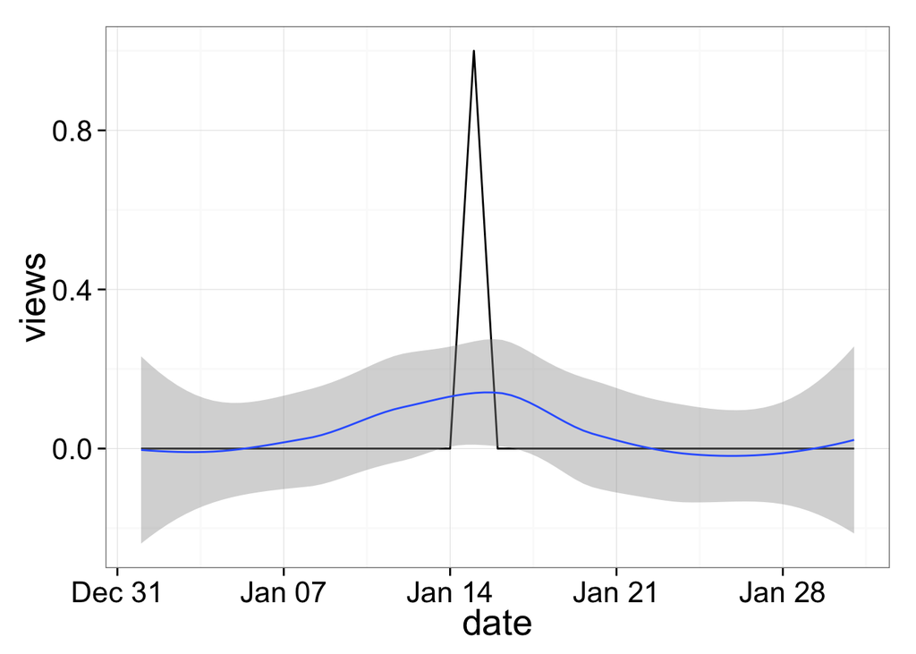

```r
require(ggplot2)
require(lubridate)
df$date <-  as.Date(rownames(df))
colnames(df) <- c("views","date")
ggplot(df,aes(date,views))+
  geom_line()+
  geom_smooth()+
  theme_bw(base_size=20)
```

Using a loop to specify specific URLs (by altering the date.)

```r
url <- data.frame(url=NA)
for (year in 2012:2013){
  for (month in 1:9){
    url[month,] <- paste("http://stats.grok.se/json/en/",year,0,month,"/web_scraping",sep="")
    }
    for (month in 10:12){
        url[month,] <- paste("http://stats.grok.se/json/en/",year,month,"/web_scraping",sep="")
    }
}
head(url)
```

```
##                                                url
## 1 http://stats.grok.se/json/en/201301/web_scraping
## 2 http://stats.grok.se/json/en/201302/web_scraping
## 3 http://stats.grok.se/json/en/201303/web_scraping
## 4 http://stats.grok.se/json/en/201304/web_scraping
## 5 http://stats.grok.se/json/en/201305/web_scraping
## 6 http://stats.grok.se/json/en/201306/web_scraping
```

Here is small function for simple web-scrapping.

```r
getData <- function(url){
  for(i in 1:nrow(url)){
    raw.data <- readLines(url[i,], warn=F)
    rd  <- fromJSON(raw.data)
    rd.views <- rd$daily_views
    rd.views <- unlist(rd.views)
    rd <- as.data.frame(rd.views)
    rd$date <- rownames(rd)
    rownames(rd) <- NULL
    assign(paste("rd",i,sep="_"),rd)
  }
  data <- data.frame()
  for(i in 1:nrow(url)){
    data <- rbind(get(paste("rd",i,sep="_")),data)
    }
  data
}
web.data <- getData(url)
dim(web.data)
```

```
## [1] 372   2
```

```r
head(web.data)
```

```
##   rd.views       date
## 1      400 2013-12-29
## 2      385 2013-12-28
## 3      524 2013-12-23
## 4      376 2013-12-22
## 5      385 2013-12-21
## 6      584 2013-12-20
```

Plotting this data

```
## geom_smooth: method="auto" and size of largest group is <1000, so using loess. Use 'method = x' to change the smoothing method.
```

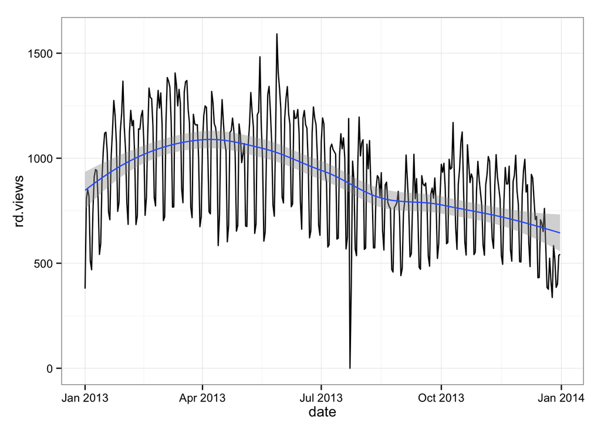

```r
web.data$date <-  as.Date(web.data$date)
ggplot(web.data,aes(x=date,y=rd.views)) +
  geom_line()+
  geom_smooth()+
  theme_bw()
```

This is a “simple” web-scrapping methodology because it’s retrieving from a (relatively) easy data structure, and something is known about the data that we are compiling. For this reason, this function works when retrieving this specific data set. However, we can expand on this later on and use some of the functionality located here down the road.

### the “rvest” package approach

`rvest` is a hadley package - play on “harvest”. See [rvest - introduction](http://blog.rstudio.org/2014/11/24/rvest-easy-web-scraping-with-r/)

```r
require(rvest)
#For specifics on selector gadget to find the css of the website, see
#vignette("selectorgadget")

#To see capability, demo the package
#demo(package = "rvest")
require(dplyr) #for the pipe
```

Let’s give it a swing pulling data similar to that of the vignette (i.e. IMDB movie data on the movie “Boyhood”)

```r
boyhood.url <- html("http://www.imdb.com/title/tt1065073/fullcredits")
cast <- html_nodes(boyhood.url,"span.itemprop")
length(cast)
```

```
## [1] 91
```

```r
df <- html_text(cast) %>% data.frame(cast=.)
df$cast <- as.character(df$cast)
head(df)
```

```
##                    cast
## 1        Ellar Coltrane
## 2     Patricia Arquette
## 3          Elijah Smith
## 4     Lorelei Linklater
## 5 Steven Chester Prince
## 6          Bonnie Cross
```

```r
#This has a list of all the actors in the movie
```

This was a simple exercise…though there are real limitations to this approach. One thing is that the selectorgadge can be a rather tedious thing to use. And even then you have to manually adapt it when you want to retrieve different pieces of information.

Here I will play with some of the versatility of the package

```r
boyhood.url <- "http://www.imdb.com/title/tt1065073/"

#Here is a way to view html pages in Rstudio.
require(httpuv)
rstudio::viewer(boyhood.url)
#htm1_session(),jump_to(), follow_link(), back(), and forward()
html_session(boyhood.url) %>% follow_link("see full cast & crew")
```

### ‘XML’ package approach - for extracting tables from the web

See [XML walkthrough - Columbia](http://www.columbia.edu/~cjd11/charles_dimaggio/DIRE/styled-4/styled-6/code-13/)

For this initial example we will be pulling from the following URL

```r
library(XML)
projects<-htmlParse("http://apps.saferoutesinfo.org/project_list/results.cfm")
class(projects) #weird document class
```

```
## [1] "HTMLInternalDocument" "HTMLInternalDocument" "XMLInternalDocument"
## [4] "XMLAbstractDocument"
```

```r
projects.table<- readHTMLTable(projects,stringsAsFactors = FALSE)
str(projects.table) #structure of the table
```

```
## List of 1
##  $ NULL:'data.frame':    6506 obs. of  11 variables:
##   ..$ State                 : chr [1:6506] "AK" "AK" "AK" "AK" ...
##   ..$ Award ID *            : chr [1:6506] "1" "3" "4" "9" ...
##   ..$ Award Amount *        : chr [1:6506] "$265,191" "$  5,000" "$100,000" "$  5,000" ...
##   ..$ Project Type **       : chr [1:6506] "1" "4" "4" "4" ...
##   ..$ Year                  : chr [1:6506] "2008" "2008" "2008" "2008" ...
##   ..$ Statewide Award ***   : chr [1:6506] "No" "No" "No" "No" ...
##   ..$ City                  : chr [1:6506] "Anchorage" "Dillingham" "Fairbanks" "Sitka" ...
##   ..$ County                : chr [1:6506] "Anchorage" "" "North Star" "" ...
##   ..$ Congressional District: chr [1:6506] "At Large" "At Large" "At Large" "At Large" ...
##   ..$ Project Summary       : chr [1:6506] "Complete Walking Route Review and Inventory. Identify walking route safety concerns. Purchase Reflective sign posts/panels" "Coordinator for Safe Routes to School program and supplies." "Hire consultants that will develop a plan for needed engineering i…
##   ..$ Schools Impacted      : chr [1:6506] "Schools" "Schools" "Schools" "Schools" ...
```

```r
expenditures<-data.frame(cbind(projects.table[[1]][1],projects.table[[1]][3])) #partialing out the arrays we want
#And like that the data is in a workable format in R.

#Cleaning the data
colnames(expenditures)[2] <- "Award.Amount"
expenditures$Award.Amount<-gsub(",", "", as.character(expenditures$Award.Amount), fixed = TRUE) #Resolving a formating issue with the amount column
expenditures$Award.Amount<-as.numeric(substring(expenditures$Award.Amount,2))
expenditures$Award.Amount[1:5]
```

```
## [1] 265191   5000 100000   5000 135980
```

```r
expenditures <- expenditures %>% group_by(State) %>% mutate(u=mean(Award.Amount),sd=sd(Award.Amount))

#Top Awar winners.
top5 <- expenditures %>% group_by(State) %>% summarize(Award.Amount=mean(Award.Amount))
str(top5)
```

```
## Classes 'tbl_df', 'tbl' and 'data.frame':    52 obs. of  2 variables:
##  $ State       : chr  "AK" "AL" "AR" "AZ" ...
##  $ Award.Amount: num  70427 180399 75498 99448 444994 ...
##  - attr(*, "drop")= logi TRUE
```

```r
top5 <- arrange(top5,desc(Award.Amount))
head(top5,5)
```

```
## Source: local data frame [5 x 2]
##
##   State Award.Amount
## 1    CA     444994.5
## 2    DC     398358.6
## 3    NY     352206.2
## 4    FL     292399.0
## 5    WA     288996.0
```

```r
projects<-htmlParse("http://apps.saferoutesinfo.org/project_list/results.cfm")
projects.table<- readHTMLTable(projects,stringsAsFactors = FALSE)
```

### ‘RCurl’ approach

```r
require(RCurl)
```